# Programming

“11. Machine Learning in Time Series”

“Wen-Bin Chuang”

“2024/07/25”

# Today’s Topics

- Validation Methods
- Feature Engineering
- Regression in Time Series
- Classification in Time Series

# Validation methods in Time Series

A very popular approach to **evaluating** models’ performance is called **cross-validation**. It is especially useful for choosing the best set of a model’s hyperparameters or selecting the best model for the problem we are trying to solve. Cross-validation is a technique that allows us to obtain reliable estimates of the model’s generalization error by providing multiple estimates of the model’s performance..

- Simple Time Split Validation The traditional validation scheme is called **k-fold cross-validation**, in which we randomly split the training data into k folds. However, k-fold cross-validation is not really suited for evaluating time series models.

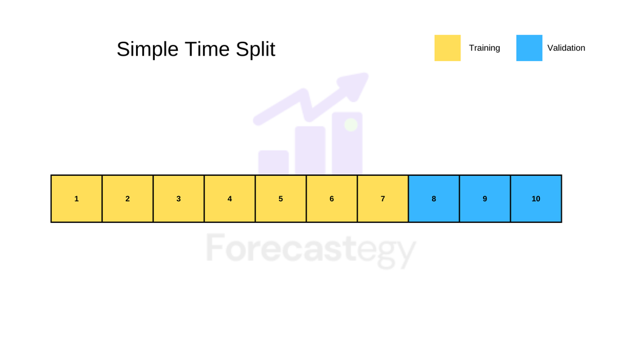

## **Walk-Forward Validation**

when dealing with time series data, the traditional cross-validation methods may not be suitable due to the **temporal nature** of the data. Time series data is characterized by its **temporal dependency**, meaning that the current value is dependent on past values. Therefore, when evaluating a time series model, it is crucial to assess its performance on unseen future data points. The most common time series cross-validation techniques is the **Walk-Forward Validation approach.**.

It is a powerful and simple technique for validating time series forecasting models. It simulates the process of forecasting by training the model on past data and predicting future points. There are two basic types: **Anchored (Expanding Window)** or **Unanchored (Rolling Window)**.

## Expanding Window Validation

Anchored walk-forward validation, is called as expanding windows, is a variation of walk-forward validation where the **training set always starts from the beginning of the dataset** and **grows** with each step, while the test set moves forward by one step at a time. This means that with each iteration, the training data includes all prior information up to the current time step, which can be beneficial for time series that may need to retain all historical information for accurate forecasting.

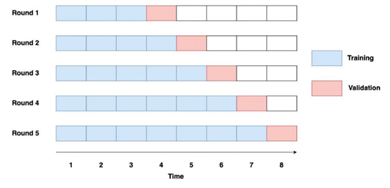

## Sliding Window Validation

Unanchored walk-forward validation, also is called rolling window validation, uses a **fixed-size training window** that “slides” forward with each step. This means that the training data for each iteration does not start from the beginning of the dataset but instead moves forward, dropping the oldest observations and adding the latest ones. This method is particularly useful when you want to keep the model focused on recent data without relying too much on older, potentially less relevant information.

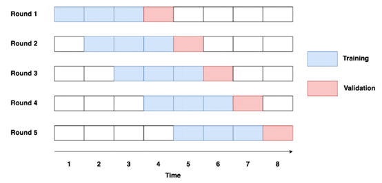

## Simple Case

**Anchored Walk-Forward Validation**: The training set grows over time since the training data includes all past observations up to that point.

- Step 1: Train on observations 1–30, test on 31.
- Step 2: Train on observations 1–31, test on 32.
- Step 3: Train on observations 1–32, test on 33.
- And so forth.

**Unanchored Walk-Forward Validation**: The training set size is fixed and “slides” forward as the validation progresses. Only the most recent observations are kept, and older data points are dropped from the training set.

- Step 1: Train on observations 1–30, test on 31.
- Step 2: Train on observations 2–31, test on 32.
- Step 3: Train on observations 3–32, test on 33.
- And so forth.

# Feature engineering

In the time series context, it means **creating informative variables** (either from the time series itself or using its timestamp) that help with getting accurate forecasts. There are many ways in which we can create features, and it comes down to a deep understanding of the dataset.

- Extracting relevant information from the timestamp. For example, we can extract the year, quarter, month, week number, or day of the week.
- Adding relevant information about special days based on the timestamp. For example, in the retail industry, we might want to add information about all holidays. To get a country-specific holiday calendar, we could use the holidays library.
- Adding lagged values of the target, similar to the AR models.
- Creating features based on aggregate values (such as minimum, maximum, mean, median, or standard deviation) over a rolling or expanding window.
- Calculating technical indicators.

# Regression Problem in Time Series

In time series analysis, a **regression problem** involves predicting a continuous numerical value based on past observations or external variables. The goal is to model the relationship between the input variables (features) and the target variable (response) over time.

**Common Applications in Finance**

1. **Stock Price/returns Prediction**
2. **Volatility Forecasting for options pricing or risk management**
3. **Interest Rate Modeling for bonds or loans**
4. **Credit Risk Assessment of default or expected loss**
5. **Portfolio Return Prediction**
6. **Economic Indicators of GDP growth, inflation rates, or unemployment rates**
7. **Cryptocurrency Price Prediction**

# Classification Problem

In finance, a **classification problem in time series** involves predicting a categorical label based on historical and/or external financial data. This is distinct from regression problems because the target variable is a class or category rather than a continuous numerical value. Classification problems are critical in finance for tasks such as decision-making, risk management, and automated trading systems.

**Common Applications of Classification in Finance**

1. **Algorithmic Trading Signals of Buy/Sell/Hold Decisions**
2. **Market Movement Prediction**
3. **Fraud Detection in banking or payments**
4. **Credit Risk Classification for loan approvals**
5. **Default Prediction**
6. **Economic Event Classification**
7. **Churn Prediction**